# Google Career Certificate: Cyclist bike share 2021

### Analysis Process

In this process, the similarities and differences between the behavior of member and casual users were studied. This analysis included the number of rides done by both users in general and through different factors like through the day, week, month, season, and year quarter. Also, it studied the average time duration and distance per each user type, the most taken routes, start point and stop point. The tool used for this analysis is **RStudio/2023.03.0+386**. As for visualizations, it was **RStudio/2023.03.0+386** and **Tableau Public 2023.1**. A dashboard was also created using **Tableau Public 2023.1**. Also, a focused tabled- report on **Excel from Microsoft Professional Plus 2019**.

*A new column was created in tableau called path station, this joins the from_station and to_station together to find the most taken road.*

#### Count of Rides Per each user_type

#### Total Number of rides

```r
#----------------------------Total of rides--------------------
#count the total number of trips
  nrow(year_2021_df_7)
```

##### Results

```r
[1] 4300941
```

#### Total number of rides per user type

```r
#count the total number of rides per each user-type
  year_2021_df_7 %>%
    count(usertype)
```

##### Results

```r
# A tibble: 2 × 2
# Rowwise:
  usertype       n
  <chr>      <int>
1 casual   1855831
2 member   2445110
```

##### Visualization

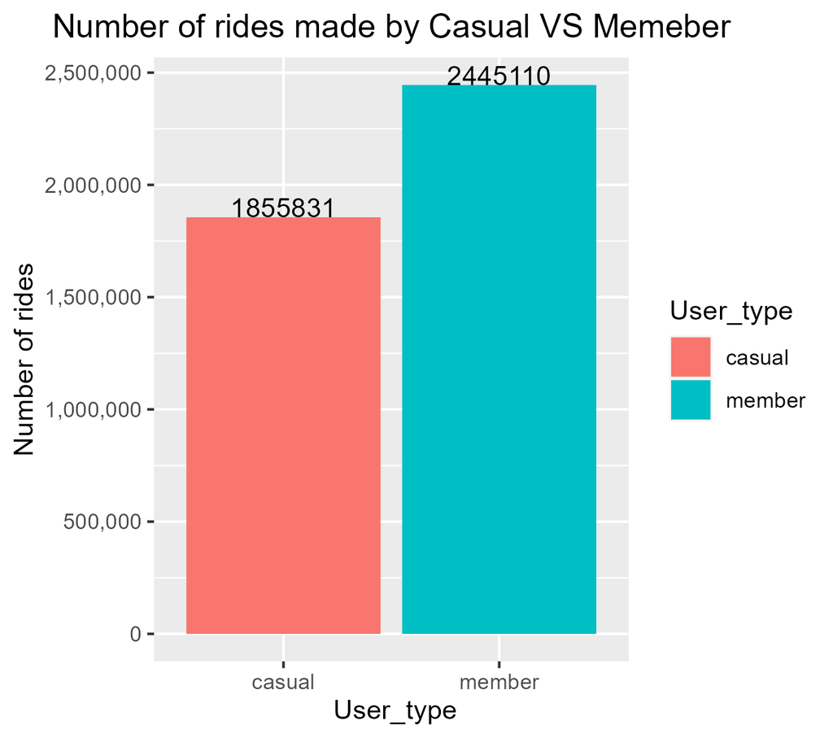

```r
#viz
ggplot(data = year_2021_df_7, mapping = aes(x= usertype, fill = usertype) ) +
  #applied the mapping here an not in the geom_bar as it will be applied to the whole built-up layers
  #as aes()in geom_function will be only applied here (hierarchy level)
  geom_bar()+
  labs(title = "Number of rides made by Casual VS Memeber", x=" User_type", y="Number of rides")+
  theme(plot.title = element_text(hjust = 0.5))+ #centering the title
  scale_y_continuous(labels = scales :: comma)+ #removing the E expression
  scale_fill_discrete(name = "User_type")+ # to change the name of the legend
  geom_text(aes(label = after_stat(count)), stat = "count", vjust = 0, colour = "black")

#ggsave("plot1-Number of rides made by Casual VS Member.png")
```

Number of rides made by different users

#### Total number of rides(bike type)

```r
#count the total ride by each bike type
  year_2021_df_7 %>%
    count(bikeid)
```

##### Results

```r
# A tibble: 3 × 2
# Rowwise:
  bikeid              n
  <chr>           <int>
1 classic_bike  3032803
2 docked_bike    247001
3 electric_bike 1021137
```

##### Visualization

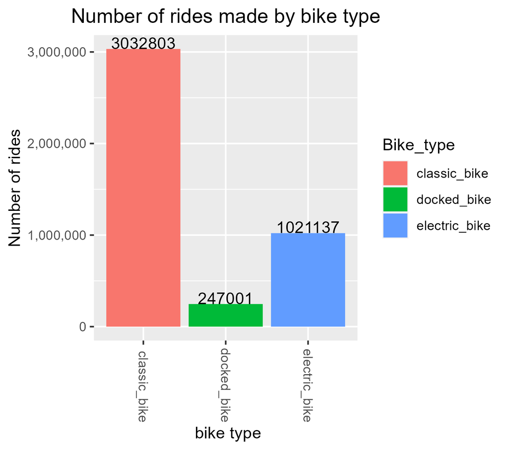

**Number of rides per each bike type**

```r
#viz
ggplot(data = year_2021_df_7, mapping = aes(x= bikeid, fill = bikeid)) +
  #applied the mapping here an not in the geom_bar as it will be applied to the whole built-up layers
  #as aes()in geom_function will be only applied here (hierarchy level)
  geom_bar()+
  labs(title = "Number of rides made by bike type",x=" bike type", y="Number of rides")+
  theme(plot.title = element_text(hjust = 0.5), axis.text.x = element_text(angle = -90, vjust = 0.5, hjust = 1))+ #centering the title
  scale_y_continuous(labels = scales :: comma)+ #removing the E expression
  scale_fill_discrete(name = "Bike_type")+ # to change the name of the legend
  geom_text(aes(label = after_stat(count)), stat = "count", vjust = 0, colour = "black")

#ggsave("plot2-Number of rides per each bike type.png")
```

#### Total of rides(user-type+bike)

```r
#----------------------------Total of rides(user-type+bike)-------------------
#count the number of the rides for each bike type per user type
  year_2021_df_7 %>%
    group_by(usertype) %>%
    count(bikeid)
```

##### Results

```r
# A tibble: 6 × 3
# Groups:   user-type [2]
  usertype bikeid              n
  <chr>    <chr>           <int>
1 casual   classic_bike  1139872
2 casual   docked_bike    247000
3 casual   electric_bike  468959
4 member   classic_bike  1892931
5 member   docked_bike         1
6 member   electric_bike  552178
```

##### Visualization

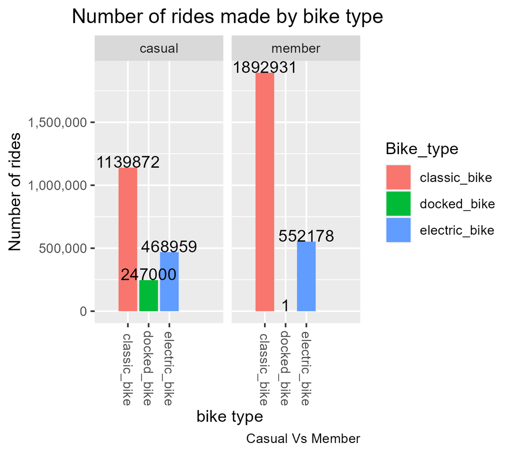

**Number of rides per each bike type Casual VS Member**

```r
#viz
ggplot(data = year_2021_df_7, mapping = aes(x= bikeid, fill = bikeid)) +
  #applied the mapping here an not in the geom_bar as it will be applied to the whole built-up layers
  #as aes()in geom_function will be only applied here (hierarchy level)
  geom_bar()+
  labs(title = "Number of rides made by bike type",caption = "Casual Vs Member",x=" bike type", y="Number of rides")+
  theme(plot.title = element_text(hjust = 0.5), axis.text.x = element_text(angle = -90, vjust = 0.5, hjust = 1))+ #centering the title
  scale_y_continuous(labels = scales :: comma)+ #removing the E expression
  scale_fill_discrete(name = "Bike_type")+ # to change the name of the legend
  geom_text(aes(label = after_stat(count)), stat = "count", vjust = 0, colour = "black")+
  facet_wrap(~usertype)

#ggsave("plot3-Number of rides per each bike type Casual VS Member.png")
```

#### Total of rides(Start_timing)

```r
#count the total number of rides per start_timing
  year_2021_df_7 %>%
    count(start_timing)
```

##### Results

```r
# A tibble: 4 × 2
# Rowwise:
  start_timing       n
  <chr>          <int>
1 Afternoon    1455981
2 Evening      1288296
3 Morning      1034497
4 Night         522167
```

```r
#count the total number of rides per start_timing and per user_type
  year_2021_df_7 %>%
    group_by(usertype) %>%
    count(start_timing)
```

##### Results

```r
# A tibble: 8 × 3
# Groups:   user type [2]
  usertype start_timing      n
  <chr>    <chr>         <int>
1 casual   Afternoon    673582
2 casual   Evening      548857
3 casual   Morning      340136
4 casual   Night        293256
5 member   Afternoon    782399
6 member   Evening      739439
7 member   Morning      694361
8 member   Night        228911
```

```r
#count the total number of rides per start_timing for each bike
  year_2021_df_7 %>%
    group_by(bikeid) %>%
    count(start_timing)
```

##### Results

```r
# A tibble: 12 × 3
# Groups:   bikeid [3]
   bikeid        start_timing       n
   <chr>         <chr>          <int>
 1 classic_bike  Afternoon    1012520
 2 classic_bike  Evening       934369
 3 classic_bike  Morning       735620
 4 classic_bike  Night         350294
 5 docked_bike   Afternoon     103142
 6 docked_bike   Evening        65610
 7 docked_bike   Morning        41147
 8 docked_bike   Night          37102
 9 electric_bike Afternoon     340319
10 electric_bike Evening       288317
11 electric_bike Morning       257730
12 electric_bike Night         134771
```

```r
#count the total number of rides per start_timing for each bike per user_type
  year_2021_df_7 %>%
    group_by(usertype,bikeid) %>%
    count(start_timing) %>%
    print(n=22)# to show the whole tibble
```

##### Results

```r
# A tibble: 21 × 4
# Groups:   usertype, bikeid [6]
   usertype bikeid        start_timing      n
   <chr>    <chr>         <chr>         <int>
 1 casual   classic_bike  Afternoon    405859
 2 casual   classic_bike  Evening      349452
 3 casual   classic_bike  Morning      204895
 4 casual   classic_bike  Night        179666
 5 casual   docked_bike   Afternoon    103142
 6 casual   docked_bike   Evening       65609
 7 casual   docked_bike   Morning       41147
 8 casual   docked_bike   Night         37102
 9 casual   electric_bike Afternoon    164581
10 casual   electric_bike Evening      133796
11 casual   electric_bike Morning       94094
12 casual   electric_bike Night         76488
13 member   classic_bike  Afternoon    606661
14 member   classic_bike  Evening      584917
15 member   classic_bike  Morning      530725
16 member   classic_bike  Night        170628
17 member   docked_bike   Evening           1
18 member   electric_bike Afternoon    175738
19 member   electric_bike Evening      154521
20 member   electric_bike Morning      163636
21 member   electric_bike Night         58283
```

##### Visualization

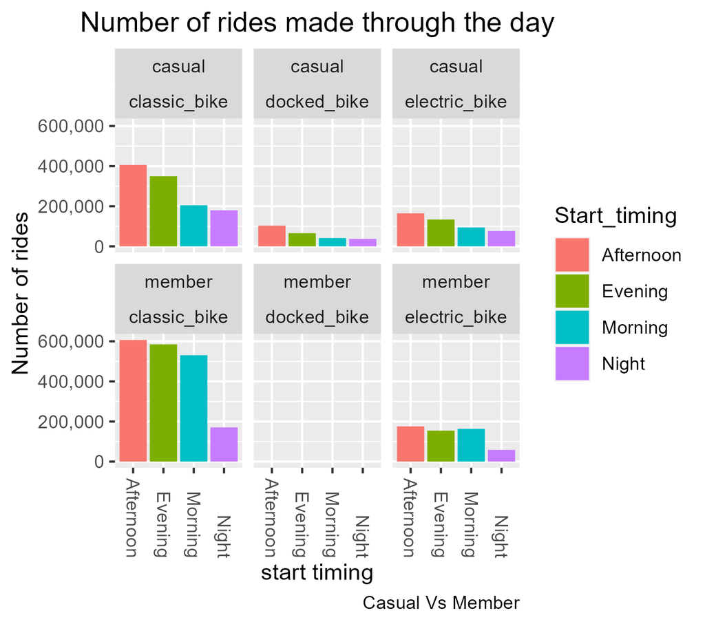

**Number of rides per each bike type Casual VS Member through the day**

```r
 #viz
  ggplot(data = year_2021_df_7, mapping = aes(x= start_timing, fill = start_timing)) +
    #applied the mapping here an not in the geom_bar as it will be applied to the whole built-up layers
    #as aes()in geom_function will be only applied here (hierarchy level)
    geom_bar()+
    labs(title = "Number of rides made through the day",caption = "Casual Vs Member",x="start timing", y="Number of rides")+
    theme(plot.title = element_text(hjust = 0.5), axis.text.x = element_text(angle = -90, vjust = 0.5, hjust = 1))+ #centering the title
    scale_y_continuous(labels = scales :: comma)+ #removing the E expression
    scale_fill_discrete(name = "Start_timing")+ # to change the name of the legend
    facet_wrap(~usertype~bikeid)

  #ggsave("plot4-Number of rides per each bike type Casual VS Member through the day.png")
```

#### Total number of rides (Hour)

```r
#----------------------------hour-------------------
#count the total number of rides per hour
  year_2021_df_7 %>%
    count(start_hour) %>%
    print(n=25)
```

##### Results

```r
# A tibble: 24 × 2
# Rowwise:
   start_hour      n
   <chr>       <int>
 1 00          61924
 2 01          43236
 3 02          26198
 4 03          14039
 5 04          11921
 6 05          33161
 7 06          87734
 8 07         160728
 9 08         191680
10 09         159838
11 10         178295
12 11         223061
13 12         261119
14 13         267120
15 14         268117
16 15         297452
17 16         362173
18 17         443229
19 18         380194
20 19         275733
21 20         189140
22 21         148577
23 22         125308
24 23          90964
```

```r
#count the total number of rides per hour for each user-type
  year_2021_df_7 %>%
    group_by(usertype) %>%
    count(start_hour) %>%
    print(n=49)
```

##### Results

```r
# A tibble: 48 × 3
# Groups:   usertype [2]
   usertype start_hour      n
   <chr>    <chr>       <int>
 1 casual   00          37539
 2 casual   01          27479
 3 casual   02          17589
 4 casual   03           9160
 5 casual   04           6102
 6 casual   05           8144
 7 casual   06          18089
 8 casual   07          33858
 9 casual   08          46041
10 casual   09          55338
11 casual   10          77047
12 casual   11         101619
13 casual   12         121028
14 casual   13         129017
15 casual   14         131900
16 casual   15         138705
17 casual   16         152932
18 casual   17         179383
19 casual   18         160654
20 casual   19         121427
21 casual   20          87393
22 casual   21          74257
23 casual   22          68717
24 casual   23          52413
25 member   00          24385
26 member   01          15757
27 member   02           8609
28 member   03           4879
29 member   04           5819
30 member   05          25017
31 member   06          69645
32 member   07         126870
33 member   08         145639
34 member   09         104500
35 member   10         101248
36 member   11         121442
37 member   12         140091
38 member   13         138103
39 member   14         136217
40 member   15         158747
41 member   16         209241
42 member   17         263846
43 member   18         219540
44 member   19         154306
45 member   20         101747
46 member   21          74320
47 member   22          56591
48 member   23          38551
```

```r
#count the total number of rides per hour for each bike id
  year_2021_df_7 %>%
    group_by(bikeid) %>%
    count(start_hour) %>%
    print(n=80)
```

##### Results

```r
# A tibble: 72 × 3
# Groups:   bikeid [3]
   bikeid        start_hour      n
   <chr>         <chr>       <int>
 1 classic_bike  00          40679
 2 classic_bike  01          28571
 3 classic_bike  02          16989
 4 classic_bike  03           8806
 5 classic_bike  04           7447
 6 classic_bike  05          23054
 7 classic_bike  06          62866
 8 classic_bike  07         116619
 9 classic_bike  08         137815
10 classic_bike  09         113360
11 classic_bike  10         125135
12 classic_bike  11         156771
13 classic_bike  12         182974
14 classic_bike  13         185598
15 classic_bike  14         185198
16 classic_bike  15         205376
17 classic_bike  16         253374
18 classic_bike  17         320914
19 classic_bike  18         279473
20 classic_bike  19         200270
21 classic_bike  20         133712
22 classic_bike  21         102281
23 classic_bike  22          84839
24 classic_bike  23          60682
25 docked_bike   00           4833
26 docked_bike   01           3385
27 docked_bike   02           2257
28 docked_bike   03           1287
29 docked_bike   04            759
30 docked_bike   05            656
31 docked_bike   06           1171
32 docked_bike   07           2329
33 docked_bike   08           3769
34 docked_bike   09           6830
35 docked_bike   10          11304
36 docked_bike   11          15088
37 docked_bike   12          18434
38 docked_bike   13          20517
39 docked_bike   14          21175
40 docked_bike   15          21188
41 docked_bike   16          21828
42 docked_bike   17          21876
43 docked_bike   18          17970
44 docked_bike   19          14609
45 docked_bike   20          11155
46 docked_bike   21           9410
47 docked_bike   22           8601
48 docked_bike   23           6570
49 electric_bike 00          16412
50 electric_bike 01          11280
51 electric_bike 02           6952
52 electric_bike 03           3946
53 electric_bike 04           3715
54 electric_bike 05           9451
55 electric_bike 06          23697
56 electric_bike 07          41780
57 electric_bike 08          50096
58 electric_bike 09          39648
59 electric_bike 10          41856
60 electric_bike 11          51202
61 electric_bike 12          59711
62 electric_bike 13          61005
63 electric_bike 14          61744
64 electric_bike 15          70888
65 electric_bike 16          86971
66 electric_bike 17         100439
67 electric_bike 18          82751
68 electric_bike 19          60854
69 electric_bike 20          44273
70 electric_bike 21          36886
71 electric_bike 22          31868
72 electric_bike 23          23712
```

```r
#count the total number of rides per hour for each bike id for each user-type
  year_2021_df_7 %>%
    group_by(usertype,bikeid) %>%
    count(start_hour) %>%
    print(n=122)
```

##### Results

```r
# A tibble: 121 × 4
# Groups:   usertype, bikeid [6]
    usertype bikeid        start_hour      n
    <chr>    <chr>         <chr>       <int>
  1 casual   classic_bike  00          22770
  2 casual   classic_bike  01          17022
  3 casual   classic_bike  02          10709
  4 casual   classic_bike  03           5238
  5 casual   classic_bike  04           3358
  6 casual   classic_bike  05           4636
  7 casual   classic_bike  06          10639
  8 casual   classic_bike  07          20129
  9 casual   classic_bike  08          27804
 10 casual   classic_bike  09          33138
 11 casual   classic_bike  10          46489
 12 casual   classic_bike  11          62060
 13 casual   classic_bike  12          73263
 14 casual   classic_bike  13          77858
 15 casual   classic_bike  14          79344
 16 casual   classic_bike  15          83311
 17 casual   classic_bike  16          92083
 18 casual   classic_bike  17         113091
 19 casual   classic_bike  18         104796
 20 casual   classic_bike  19          77464
 21 casual   classic_bike  20          54101
 22 casual   classic_bike  21          45739
 23 casual   classic_bike  22          42452
 24 casual   classic_bike  23          32378
 25 casual   docked_bike   00           4833
 26 casual   docked_bike   01           3385
 27 casual   docked_bike   02           2257
 28 casual   docked_bike   03           1287
 29 casual   docked_bike   04            759
 30 casual   docked_bike   05            656
 31 casual   docked_bike   06           1171
 32 casual   docked_bike   07           2329
 33 casual   docked_bike   08           3769
 34 casual   docked_bike   09           6830
 35 casual   docked_bike   10          11304
 36 casual   docked_bike   11          15088
 37 casual   docked_bike   12          18434
 38 casual   docked_bike   13          20517
 39 casual   docked_bike   14          21175
 40 casual   docked_bike   15          21188
 41 casual   docked_bike   16          21828
 42 casual   docked_bike   17          21876
 43 casual   docked_bike   18          17969
 44 casual   docked_bike   19          14609
 45 casual   docked_bike   20          11155
 46 casual   docked_bike   21           9410
 47 casual   docked_bike   22           8601
 48 casual   docked_bike   23           6570
 49 casual   electric_bike 00           9936
 50 casual   electric_bike 01           7072
 51 casual   electric_bike 02           4623
 52 casual   electric_bike 03           2635
 53 casual   electric_bike 04           1985
 54 casual   electric_bike 05           2852
 55 casual   electric_bike 06           6279
 56 casual   electric_bike 07          11400
 57 casual   electric_bike 08          14468
 58 casual   electric_bike 09          15370
 59 casual   electric_bike 10          19254
 60 casual   electric_bike 11          24471
 61 casual   electric_bike 12          29331
 62 casual   electric_bike 13          30642
 63 casual   electric_bike 14          31381
 64 casual   electric_bike 15          34206
 65 casual   electric_bike 16          39021
 66 casual   electric_bike 17          44416
 67 casual   electric_bike 18          37889
 68 casual   electric_bike 19          29354
 69 casual   electric_bike 20          22137
 70 casual   electric_bike 21          19108
 71 casual   electric_bike 22          17664
 72 casual   electric_bike 23          13465
 73 member   classic_bike  00          17909
 74 member   classic_bike  01          11549
 75 member   classic_bike  02           6280
 76 member   classic_bike  03           3568
 77 member   classic_bike  04           4089
 78 member   classic_bike  05          18418
 79 member   classic_bike  06          52227
 80 member   classic_bike  07          96490
 81 member   classic_bike  08         110011
 82 member   classic_bike  09          80222
 83 member   classic_bike  10          78646
 84 member   classic_bike  11          94711
 85 member   classic_bike  12         109711
 86 member   classic_bike  13         107740
 87 member   classic_bike  14         105854
 88 member   classic_bike  15         122065
 89 member   classic_bike  16         161291
 90 member   classic_bike  17         207823
 91 member   classic_bike  18         174677
 92 member   classic_bike  19         122806
 93 member   classic_bike  20          79611
 94 member   classic_bike  21          56542
 95 member   classic_bike  22          42387
 96 member   classic_bike  23          28304
 97 member   docked_bike   18              1
 98 member   electric_bike 00           6476
 99 member   electric_bike 01           4208
100 member   electric_bike 02           2329
101 member   electric_bike 03           1311
102 member   electric_bike 04           1730
103 member   electric_bike 05           6599
104 member   electric_bike 06          17418
105 member   electric_bike 07          30380
106 member   electric_bike 08          35628
107 member   electric_bike 09          24278
108 member   electric_bike 10          22602
109 member   electric_bike 11          26731
110 member   electric_bike 12          30380
111 member   electric_bike 13          30363
112 member   electric_bike 14          30363
113 member   electric_bike 15          36682
114 member   electric_bike 16          47950
115 member   electric_bike 17          56023
116 member   electric_bike 18          44862
117 member   electric_bike 19          31500
118 member   electric_bike 20          22136
119 member   electric_bike 21          17778
120 member   electric_bike 22          14204
121 member   electric_bike 23          10247
```

```r
#count the total number of rides per hour for each bike id for each user-type and
 #start-timing to get the busy hour for each category
  year_2021_df_7 %>%
    group_by(usertype,bikeid,start_timing) %>%
    count(start_hour) %>%
    print(n=122)
```

##### Results

```r
# A tibble: 121 × 5
# Groups:   usertype, bikeid, start_timing [21]
    usertype bikeid        start_timing start_hour      n
    <chr>    <chr>         <chr>        <chr>       <int>
  1 casual   classic_bike  Afternoon    12          73263
  2 casual   classic_bike  Afternoon    13          77858
  3 casual   classic_bike  Afternoon    14          79344
  4 casual   classic_bike  Afternoon    15          83311
  5 casual   classic_bike  Afternoon    16          92083
  6 casual   classic_bike  Evening      17         113091
  7 casual   classic_bike  Evening      18         104796
  8 casual   classic_bike  Evening      19          77464
  9 casual   classic_bike  Evening      20          54101
 10 casual   classic_bike  Morning      05           4636
 11 casual   classic_bike  Morning      06          10639
 12 casual   classic_bike  Morning      07          20129
 13 casual   classic_bike  Morning      08          27804
 14 casual   classic_bike  Morning      09          33138
 15 casual   classic_bike  Morning      10          46489
 16 casual   classic_bike  Morning      11          62060
 17 casual   classic_bike  Night        00          22770
 18 casual   classic_bike  Night        01          17022
 19 casual   classic_bike  Night        02          10709
 20 casual   classic_bike  Night        03           5238
 21 casual   classic_bike  Night        04           3358
 22 casual   classic_bike  Night        21          45739
 23 casual   classic_bike  Night        22          42452
 24 casual   classic_bike  Night        23          32378
 25 casual   docked_bike   Afternoon    12          18434
 26 casual   docked_bike   Afternoon    13          20517
 27 casual   docked_bike   Afternoon    14          21175
 28 casual   docked_bike   Afternoon    15          21188
 29 casual   docked_bike   Afternoon    16          21828
 30 casual   docked_bike   Evening      17          21876
 31 casual   docked_bike   Evening      18          17969
 32 casual   docked_bike   Evening      19          14609
 33 casual   docked_bike   Evening      20          11155
 34 casual   docked_bike   Morning      05            656
 35 casual   docked_bike   Morning      06           1171
 36 casual   docked_bike   Morning      07           2329
 37 casual   docked_bike   Morning      08           3769
 38 casual   docked_bike   Morning      09           6830
 39 casual   docked_bike   Morning      10          11304
 40 casual   docked_bike   Morning      11          15088
 41 casual   docked_bike   Night        00           4833
 42 casual   docked_bike   Night        01           3385
 43 casual   docked_bike   Night        02           2257
 44 casual   docked_bike   Night        03           1287
 45 casual   docked_bike   Night        04            759
 46 casual   docked_bike   Night        21           9410
 47 casual   docked_bike   Night        22           8601
 48 casual   docked_bike   Night        23           6570
 49 casual   electric_bike Afternoon    12          29331
 50 casual   electric_bike Afternoon    13          30642
 51 casual   electric_bike Afternoon    14          31381
 52 casual   electric_bike Afternoon    15          34206
 53 casual   electric_bike Afternoon    16          39021
 54 casual   electric_bike Evening      17          44416
 55 casual   electric_bike Evening      18          37889
 56 casual   electric_bike Evening      19          29354
 57 casual   electric_bike Evening      20          22137
 58 casual   electric_bike Morning      05           2852
 59 casual   electric_bike Morning      06           6279
 60 casual   electric_bike Morning      07          11400
 61 casual   electric_bike Morning      08          14468
 62 casual   electric_bike Morning      09          15370
 63 casual   electric_bike Morning      10          19254
 64 casual   electric_bike Morning      11          24471
 65 casual   electric_bike Night        00           9936
 66 casual   electric_bike Night        01           7072
 67 casual   electric_bike Night        02           4623
 68 casual   electric_bike Night        03           2635
 69 casual   electric_bike Night        04           1985
 70 casual   electric_bike Night        21          19108
 71 casual   electric_bike Night        22          17664
 72 casual   electric_bike Night        23          13465
 73 member   classic_bike  Afternoon    12         109711
 74 member   classic_bike  Afternoon    13         107740
 75 member   classic_bike  Afternoon    14         105854
 76 member   classic_bike  Afternoon    15         122065
 77 member   classic_bike  Afternoon    16         161291
 78 member   classic_bike  Evening      17         207823
 79 member   classic_bike  Evening      18         174677
 80 member   classic_bike  Evening      19         122806
 81 member   classic_bike  Evening      20          79611
 82 member   classic_bike  Morning      05          18418
 83 member   classic_bike  Morning      06          52227
 84 member   classic_bike  Morning      07          96490
 85 member   classic_bike  Morning      08         110011
 86 member   classic_bike  Morning      09          80222
 87 member   classic_bike  Morning      10          78646
 88 member   classic_bike  Morning      11          94711
 89 member   classic_bike  Night        00          17909
 90 member   classic_bike  Night        01          11549
 91 member   classic_bike  Night        02           6280
 92 member   classic_bike  Night        03           3568
 93 member   classic_bike  Night        04           4089
 94 member   classic_bike  Night        21          56542
 95 member   classic_bike  Night        22          42387
 96 member   classic_bike  Night        23          28304
 97 member   docked_bike   Evening      18              1
 98 member   electric_bike Afternoon    12          30380
 99 member   electric_bike Afternoon    13          30363
100 member   electric_bike Afternoon    14          30363
101 member   electric_bike Afternoon    15          36682
102 member   electric_bike Afternoon    16          47950
103 member   electric_bike Evening      17          56023
104 member   electric_bike Evening      18          44862
105 member   electric_bike Evening      19          31500
106 member   electric_bike Evening      20          22136
107 member   electric_bike Morning      05           6599
108 member   electric_bike Morning      06          17418
109 member   electric_bike Morning      07          30380
110 member   electric_bike Morning      08          35628
111 member   electric_bike Morning      09          24278
112 member   electric_bike Morning      10          22602
113 member   electric_bike Morning      11          26731
114 member   electric_bike Night        00           6476
115 member   electric_bike Night        01           4208
116 member   electric_bike Night        02           2329
117 member   electric_bike Night        03           1311
118 member   electric_bike Night        04           1730
119 member   electric_bike Night        21          17778
120 member   electric_bike Night        22          14204
121 member   electric_bike Night        23          10247
```

##### Visualization

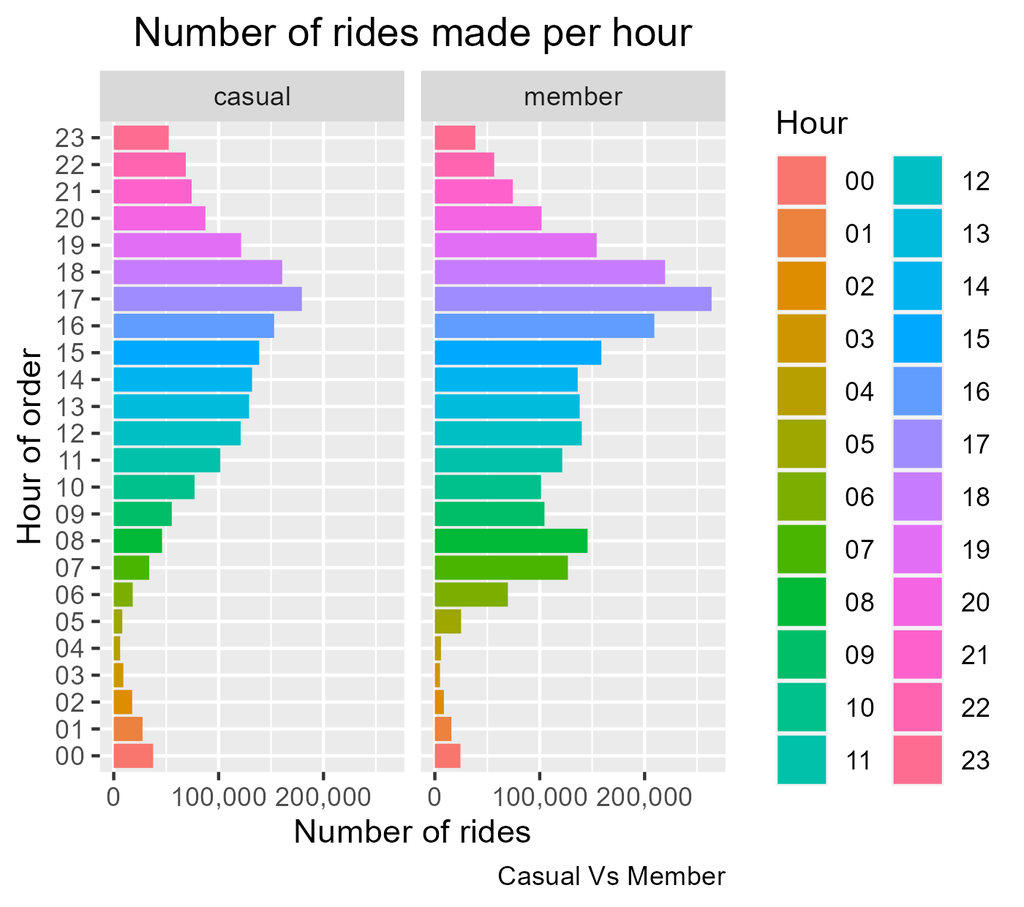

**Number of rides per hour**

```r
#viz
  ggplot(data = year_2021_df_7, mapping = aes(y= start_hour, fill = start_hour)) +
    #applied the mapping here an not in the geom_bar as it will be applied to the whole built-up layers
    #as aes()in geom_function will be only applied here (hierarchy level)
    geom_bar()+
    labs(title = "Number of rides made per hour",caption = "Casual Vs Member",y="Hour of order", x="Number of rides")+
    theme(plot.title = element_text(hjust = 0.5))+ #centering the title
    scale_x_continuous(labels = scales :: comma)+ #removing the E expression
    scale_fill_discrete(name = "Hour")+ # to change the name of the legend
    facet_grid(~usertype)

  #ggsave("plot5-Number of rides per hour.png")
```

#### Total Number of rides(Day)

```r
#----------------------------day-------------------
#count the total number of rides per each day
  year_2021_df_7 %>%
    count(day_of_order)
```

##### Results

```r
# A tibble: 7 × 2
# Rowwise:
  day_of_order      n
  <chr>         <int>
1 Friday       619393
2 Monday       537042
3 Saturday     768328
4 Sunday       656482
5 Thursday     567250
6 Tuesday      569082
7 Wednesday    583364
```

```r
#count the total number of rides per each day for each user-type
  year_2021_df_7 %>%
    group_by(usertype) %>%
    count(day_of_order)
```

##### Results

```r
# A tibble: 14 × 3
# Groups:   usertype [2]
   usertype day_of_order      n
   <chr>    <chr>         <int>
 1 casual   Friday       266591
 2 casual   Monday       204025
 3 casual   Saturday     425797
 4 casual   Sunday       359535
 5 casual   Thursday     206358
 6 casual   Tuesday      194436
 7 casual   Wednesday    199089
 8 member   Friday       352802
 9 member   Monday       333017
10 member   Saturday     342531
11 member   Sunday       296947
12 member   Thursday     360892
13 member   Tuesday      374646
14 member   Wednesday    384275
```

```r
#count the total number of rides per each day for each bike id
  year_2021_df_7 %>%
    group_by(bikeid) %>%
    count(day_of_order) %>%
    print(n=22)
```

##### Results

```r
# A tibble: 21 × 3
# Groups:   bikeid [3]
   bikeid        day_of_order      n
   <chr>         <chr>         <int>
 1 classic_bike  Friday       430521
 2 classic_bike  Monday       377183
 3 classic_bike  Saturday     545073
 4 classic_bike  Sunday       467606
 5 classic_bike  Thursday     401147
 6 classic_bike  Tuesday      398373
 7 classic_bike  Wednesday    412900
 8 docked_bike   Friday        34368
 9 docked_bike   Monday        27905
10 docked_bike   Saturday      63685
11 docked_bike   Sunday        54545
12 docked_bike   Thursday      22129
13 docked_bike   Tuesday       22654
14 docked_bike   Wednesday     21715
15 electric_bike Friday       154504
16 electric_bike Monday       131954
17 electric_bike Saturday     159570
18 electric_bike Sunday       134331
19 electric_bike Thursday     143974
20 electric_bike Tuesday      148055
21 electric_bike Wednesday    148749
```

```r
#count the total number of rides per each day for each bike id for each user-type
  year_2021_df_7 %>%
    group_by(usertype,bikeid) %>%
    count(day_of_order) %>%
    print(n=36)
```

##### Results

```r
# A tibble: 36 × 4
# Groups:   usertype, bikeid [6]
   usertype bikeid        day_of_order      n
   <chr>    <chr>         <chr>         <int>
 1 casual   classic_bike  Friday       161224
 2 casual   classic_bike  Monday       119641
 3 casual   classic_bike  Saturday     273369
 4 casual   classic_bike  Sunday       229010
 5 casual   classic_bike  Thursday     125237
 6 casual   classic_bike  Tuesday      112669
 7 casual   classic_bike  Wednesday    118722
 8 casual   docked_bike   Friday        34368
 9 casual   docked_bike   Monday        27905
10 casual   docked_bike   Saturday      63685
11 casual   docked_bike   Sunday        54545
12 casual   docked_bike   Thursday      22129
13 casual   docked_bike   Tuesday       22654
14 casual   docked_bike   Wednesday     21714
15 casual   electric_bike Friday        70999
16 casual   electric_bike Monday        56479
17 casual   electric_bike Saturday      88743
18 casual   electric_bike Sunday        75980
19 casual   electric_bike Thursday      58992
20 casual   electric_bike Tuesday       59113
21 casual   electric_bike Wednesday     58653
22 member   classic_bike  Friday       269297
23 member   classic_bike  Monday       257542
24 member   classic_bike  Saturday     271704
25 member   classic_bike  Sunday       238596
26 member   classic_bike  Thursday     275910
27 member   classic_bike  Tuesday      285704
28 member   classic_bike  Wednesday    294178
29 member   docked_bike   Wednesday         1
30 member   electric_bike Friday        83505
31 member   electric_bike Monday        75475
32 member   electric_bike Saturday      70827
33 member   electric_bike Sunday        58351
34 member   electric_bike Thursday      84982
35 member   electric_bike Tuesday       88942
36 member   electric_bike Wednesday     90096
```

```r
#count the total number of rides to know the busy day for start timing
  year_2021_df_7 %>%
    group_by(day_of_order) %>%
    count(start_timing) %>%
    print(n=2000)
```

##### Results

```r
# A tibble: 28 × 3
# Groups:   day_of_order [7]
   day_of_order start_timing      n
   <chr>        <chr>         <int>
 1 Friday       Afternoon    206081
 2 Friday       Evening      190997
 3 Friday       Morning      142968
 4 Friday       Night         79347
 5 Monday       Afternoon    173540
 6 Monday       Evening      177448
 7 Monday       Morning      137065
 8 Monday       Night         48989
 9 Saturday     Afternoon    303651
10 Saturday     Evening      174823
11 Saturday     Morning      166744
12 Saturday     Night        123110
13 Sunday       Afternoon    276742
14 Sunday       Evening      145008
15 Sunday       Morning      138489
16 Sunday       Night         96243
17 Thursday     Afternoon    162224
18 Thursday     Evening      195288
19 Thursday     Morning      143724
20 Thursday     Night         66014
21 Tuesday      Afternoon    167637
22 Tuesday      Evening      199117
23 Tuesday      Morning      151849
24 Tuesday      Night         50479
25 Wednesday    Afternoon    166106
26 Wednesday    Evening      205615
27 Wednesday    Morning      153658
28 Wednesday    Night         57985
```

```r
#count the total number of rides per each day for each hour per start timing
  year_2021_df_7 %>%
    group_by(start_hour, start_timing ) %>%
    count(day_of_order) %>%
    print(n=200)
```

##### Results

```r
# A tibble: 168 × 4
# Groups:   start_hour, start_timing [24]
    start_hour start_timing day_of_order     n
    <chr>      <chr>        <chr>        <int>
  1 00         Night        Friday        7405
  2 00         Night        Monday        4927
  3 00         Night        Saturday     17064
  4 00         Night        Sunday       20972
  5 00         Night        Thursday      4589
  6 00         Night        Tuesday       3157
  7 00         Night        Wednesday     3810
  8 01         Night        Friday        4454
  9 01         Night        Monday        2889
 10 01         Night        Saturday     14704
 11 01         Night        Sunday       15751
 12 01         Night        Thursday      2194
 13 01         Night        Tuesday       1609
 14 01         Night        Wednesday     1635
 15 02         Night        Friday        2181
 16 02         Night        Monday        1774
 17 02         Night        Saturday      8856
 18 02         Night        Sunday       10352
 19 02         Night        Thursday      1138
 20 02         Night        Tuesday        924
 21 02         Night        Wednesday      973
 22 03         Night        Friday        1272
 23 03         Night        Monday        1182
 24 03         Night        Saturday      4047
 25 03         Night        Sunday        5478
 26 03         Night        Thursday       770
 27 03         Night        Tuesday        652
 28 03         Night        Wednesday      638
 29 04         Night        Friday        1384
 30 04         Night        Monday        1650
 31 04         Night        Saturday      2240
 32 04         Night        Sunday        3085
 33 04         Night        Thursday      1193
 34 04         Night        Tuesday       1176
 35 04         Night        Wednesday     1193
 36 05         Morning      Friday        4933
 37 05         Morning      Monday        5190
 38 05         Morning      Saturday      2619
 39 05         Morning      Sunday        2717
 40 05         Morning      Thursday      5519
 41 05         Morning      Tuesday       6222
 42 05         Morning      Wednesday     5961
 43 06         Morning      Friday       13543
 44 06         Morning      Monday       14218
 45 06         Morning      Saturday      5608
 46 06         Morning      Sunday        4915
 47 06         Morning      Thursday     15348
 48 06         Morning      Tuesday      17179
 49 06         Morning      Wednesday    16923
 50 07         Morning      Friday       23976
 51 07         Morning      Monday       25574
 52 07         Morning      Saturday     10503
 53 07         Morning      Sunday        8205
 54 07         Morning      Thursday     28638
 55 07         Morning      Tuesday      31919
 56 07         Morning      Wednesday    31913
 57 08         Morning      Friday       27909
 58 08         Morning      Monday       28628
 59 08         Morning      Saturday     18973
 60 08         Morning      Sunday       14140
 61 08         Morning      Thursday     32128
 62 08         Morning      Tuesday      34571
 63 08         Morning      Wednesday    35331
 64 09         Morning      Friday       21496
 65 09         Morning      Monday       19320
 66 09         Morning      Saturday     30865
 67 09         Morning      Sunday       24324
 68 09         Morning      Thursday     20528
 69 09         Morning      Tuesday      21307
 70 09         Morning      Wednesday    21998
 71 10         Morning      Friday       22508
 72 10         Morning      Monday       19307
 73 10         Morning      Saturday     44276
 74 10         Morning      Sunday       36983
 75 10         Morning      Thursday     18571
 76 10         Morning      Tuesday      18143
 77 10         Morning      Wednesday    18507
 78 11         Morning      Friday       28603
 79 11         Morning      Monday       24828
 80 11         Morning      Saturday     53900
 81 11         Morning      Sunday       47205
 82 11         Morning      Thursday     22992
 83 11         Morning      Tuesday      22508
 84 11         Morning      Wednesday    23025
 85 12         Afternoon    Friday       34814
 86 12         Afternoon    Monday       30144
 87 12         Afternoon    Saturday     60219
 88 12         Afternoon    Sunday       53407
 89 12         Afternoon    Thursday     27150
 90 12         Afternoon    Tuesday      27527
 91 12         Afternoon    Wednesday    27858
 92 13         Afternoon    Friday       36197
 93 13         Afternoon    Monday       30247
 94 13         Afternoon    Saturday     63062
 95 13         Afternoon    Sunday       55796
 96 13         Afternoon    Thursday     26573
 97 13         Afternoon    Tuesday      27873
 98 13         Afternoon    Wednesday    27372
 99 14         Afternoon    Friday       37471
100 14         Afternoon    Monday       30286
101 14         Afternoon    Saturday     62400
102 14         Afternoon    Sunday       55659
103 14         Afternoon    Thursday     27117
104 14         Afternoon    Tuesday      27754
105 14         Afternoon    Wednesday    27430
106 15         Afternoon    Friday       43134
107 15         Afternoon    Monday       35225
108 15         Afternoon    Saturday     60031
109 15         Afternoon    Sunday       57282
110 15         Afternoon    Thursday     33420
111 15         Afternoon    Tuesday      34541
112 15         Afternoon    Wednesday    33819
113 16         Afternoon    Friday       54465
114 16         Afternoon    Monday       47638
115 16         Afternoon    Saturday     57939
116 16         Afternoon    Sunday       54598
117 16         Afternoon    Thursday     47964
118 16         Afternoon    Tuesday      49942
119 16         Afternoon    Wednesday    49627
120 17         Evening      Friday       64906
121 17         Evening      Monday       63112
122 17         Evening      Saturday     55037
123 17         Evening      Sunday       49406
124 17         Evening      Thursday     66298
125 17         Evening      Tuesday      72130
126 17         Evening      Wednesday    72340
127 18         Evening      Friday       56900
128 18         Evening      Monday       53031
129 18         Evening      Saturday     49619
130 18         Evening      Sunday       41159
131 18         Evening      Thursday     58512
132 18         Evening      Tuesday      59757
133 18         Evening      Wednesday    61216
134 19         Evening      Friday       41291
135 19         Evening      Monday       36945
136 19         Evening      Saturday     40155
137 19         Evening      Sunday       31636
138 19         Evening      Thursday     41820
139 19         Evening      Tuesday      40960
140 19         Evening      Wednesday    42926
141 20         Evening      Friday       27900
142 20         Evening      Monday       24360
143 20         Evening      Saturday     30012
144 20         Evening      Sunday       22807
145 20         Evening      Thursday     28658
146 20         Evening      Tuesday      26270
147 20         Evening      Wednesday    29133
148 21         Night        Friday       22370
149 21         Night        Monday       17432
150 21         Night        Saturday     25650
151 21         Night        Sunday       17580
152 21         Night        Thursday     23024
153 21         Night        Tuesday      19433
154 21         Night        Wednesday    23088
155 22         Night        Friday       20551
156 22         Night        Monday       12402
157 22         Night        Saturday     25947
158 22         Night        Sunday       14278
159 22         Night        Thursday     19902
160 22         Night        Tuesday      15125
161 22         Night        Wednesday    17103
162 23         Night        Friday       19730
163 23         Night        Monday        6733
164 23         Night        Saturday     24602
165 23         Night        Sunday        8747
166 23         Night        Thursday     13204
167 23         Night        Tuesday       8403
168 23         Night        Wednesday     9545
```

```r
#count the total number of rides per each day for each hour per start timing for each bike id for each user-type
  year_2021_df_7 %>%
    group_by(usertype, bikeid,start_hour, start_timing ) %>%
    count(day_of_order) %>%
    print(n=200)
```

##### Results

```r
# A tibble: 841 × 6
# Groups:   usertype, bikeid, start_hour, start_timing [121]
   usertype bikeid       start_hour start_timing day_of_order     n
   <chr>    <chr>        <chr>      <chr>        <chr>        <int>
 1 casual   classic_bike 00         Night        Friday        2472
 2 casual   classic_bike 00         Night        Monday        1721
 3 casual   classic_bike 00         Night        Saturday      6616
 4 casual   classic_bike 00         Night        Sunday        8602
 5 casual   classic_bike 00         Night        Thursday      1394
 6 casual   classic_bike 00         Night        Tuesday        870
 7 casual   classic_bike 00         Night        Wednesday     1095
 8 casual   classic_bike 01         Night        Friday        1589
 9 casual   classic_bike 01         Night        Monday        1032
10 casual   classic_bike 01         Night        Saturday      6217
# … with 831 more rows
# ℹ Use `print(n = ...)` to see more rows
```

##### Visualization

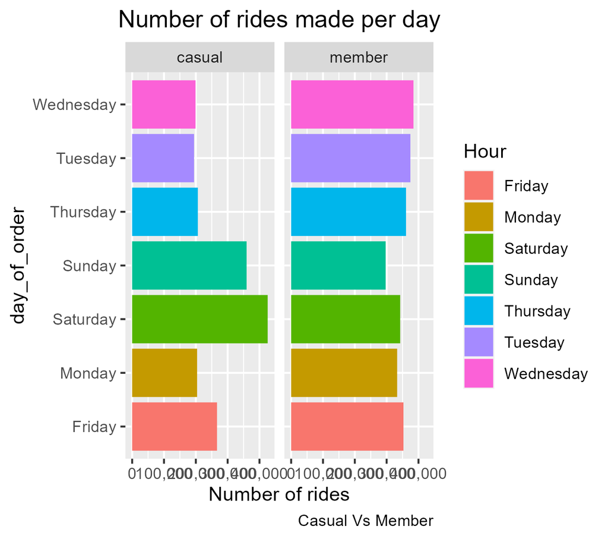

**Number of rides per day**

```r
#viz
  ggplot(data = year_2021_df_7, mapping = aes(y= day_of_order, fill = day_of_order)) +
    #applied the mapping here an not in the geom_bar as it will be applied to the whole built-up layers
    #as aes()in geom_function will be only applied here (hierarchy level)
    geom_bar()+
    labs(title = "Number of rides made per day",caption = "Casual Vs Member",y="day_of_order", x="Number of rides")+
    theme(plot.title = element_text(hjust = 0.5))+ #centering the title
    scale_x_continuous(labels = scales :: comma)+ #removing the E expression
    scale_fill_discrete(name = "Hour")+ # to change the name of the legend
    facet_grid(~usertype)

  #ggsave("plot6-Number of rides per day.png")
```

#### Total number of rides(Month)

```r
#----------------------------Month-------------------
#count the total number of rides per each month
  year_2021_df_7 %>%
    count(month)
```

##### Results

```r
# A tibble: 12 × 2
# Rowwise:
   month          n
   <chr>      <int>
 1 April     273257
 2 August    633825
 3 December  169964
 4 February   40128
 5 January    79652
 6 July      646656
 7 June      564492
 8 March     189092
 9 May       414823
10 November  246379
11 October   455885
12 September 586788
```

```r
#count the total number of rides per each month per user-type
  year_2021_df_7 %>%
    group_by(usertype) %>%
    count(month) %>%
    print(n=24)
```

##### Results

```r
# A tibble: 24 × 3
# Groups:   usertype [2]
   usertype month          n
   <chr>    <chr>      <int>
 1 casual   April     103298
 2 casual   August    313231
 3 casual   December   42237
 4 casual   February    7547
 5 casual   January    13230
 6 casual   July      336030
 7 casual   June      272036
 8 casual   March      64713
 9 casual   May       190354
10 casual   November   65961
11 casual   October   176865
12 casual   September 270329
13 member   April     169959
14 member   August    320594
15 member   December  127727
16 member   February   32581
17 member   January    66422
18 member   July      310626
19 member   June      292456
20 member   March     124379
21 member   May       224469
22 member   November  180418
23 member   October   279020
24 member   September 316459
```

```r
#count the total number of rides per each month per bike
  year_2021_df_7 %>%
    group_by(bikeid) %>%
    count(month) %>%
    print(n=36)
```

##### Results

```r
# A tibble: 36 × 3
# Groups:   bikeid [3]
   bikeid        month          n
   <chr>         <chr>      <int>
 1 classic_bike  April     196948
 2 classic_bike  August    471082
 3 classic_bike  December   95577
 4 classic_bike  February   32149
 5 classic_bike  January    58246
 6 classic_bike  July      472362
 7 classic_bike  June      402555
 8 classic_bike  March     140357
 9 classic_bike  May       283957
10 classic_bike  November  146550
11 classic_bike  October   298343
12 classic_bike  September 434677
13 docked_bike   April      17523
14 docked_bike   August     36801
15 docked_bike   December    4088
16 docked_bike   February     969
17 docked_bike   January     1589
18 docked_bike   July       46743
19 docked_bike   June       40142
20 docked_bike   March      11218
21 docked_bike   May        32669
22 docked_bike   November    6515
23 docked_bike   October    19430
24 docked_bike   September  29314
25 electric_bike April      58786
26 electric_bike August    125942
27 electric_bike December   70299
28 electric_bike February    7010
29 electric_bike January    19817
30 electric_bike July      127551
31 electric_bike June      121795
32 electric_bike March      37517
33 electric_bike May        98197
34 electric_bike November   93314
35 electric_bike October   138112
36 electric_bike September 122797
```

```r
#count the total number of rides per each month to know the busy day
  year_2021_df_7 %>%
    group_by(month) %>%
    count(day_of_order) %>%
    print(n=100)
```

##### Results

```r
# A tibble: 84 × 3
# Groups:   month [12]
   month     day_of_order      n
   <chr>     <chr>         <int>
 1 April     Friday        48121
 2 April     Monday        35358
 3 April     Saturday      44142
 4 April     Sunday        40211
 5 April     Thursday      33082
 6 April     Tuesday       41763
 7 April     Wednesday     30580
 8 August    Friday        87681
 9 August    Monday        85360
10 August    Saturday     108119
11 August    Sunday       112191
12 August    Thursday      80416
13 August    Tuesday       87152
14 August    Wednesday     72906
15 December  Friday        28629
16 December  Monday        21228
17 December  Saturday      20047
18 December  Sunday        15768
19 December  Thursday      33061
20 December  Tuesday       20113
21 December  Wednesday     31118
22 February  Friday         6471
23 February  Monday         3699
24 February  Saturday       8034
25 February  Sunday         4363
26 February  Thursday       5760
27 February  Tuesday        5488
28 February  Wednesday      6313
29 January   Friday        12618
30 January   Monday        10964
31 January   Saturday      13269
32 January   Sunday         9491
33 January   Thursday      11883
34 January   Tuesday       10361
35 January   Wednesday     11066
36 July      Friday       106684
37 July      Monday        74002
38 July      Saturday     129396
39 July      Sunday        85169
40 July      Thursday      96085
41 July      Tuesday       76465
42 July      Wednesday     78855
43 June      Friday        77544
44 June      Monday        60849
45 June      Saturday      94343
46 June      Sunday        88126
47 June      Thursday      70206
48 June      Tuesday       84793
49 June      Wednesday     88631
50 March     Friday        21555
51 March     Monday        28528
52 March     Saturday      37511
53 March     Sunday        28940
54 March     Thursday      18127
55 March     Tuesday       28090
56 March     Wednesday     26341
57 May       Friday        51368
58 May       Monday        59015
59 May       Saturday      87746
60 May       Sunday        80493
61 May       Thursday      45988
62 May       Tuesday       41098
63 May       Wednesday     49115
64 November  Friday        28725
65 November  Monday        41463
66 November  Saturday      33924
67 November  Sunday        29827
68 November  Thursday      28555
69 November  Tuesday       46955
70 November  Wednesday     36930
71 October   Friday        71008
72 October   Monday        45730
73 October   Saturday      94529
74 October   Sunday        72634
75 October   Thursday      48909
76 October   Tuesday       61918
77 October   Wednesday     61157
78 September Friday        78989
79 September Monday        70846
80 September Saturday      97268
81 September Sunday        89269
82 September Thursday      95178
83 September Tuesday       64886
84 September Wednesday     90352
```

```r
#count the total number of rides per each month to know the busy day for start timing and hour
  year_2021_df_7 %>%
    group_by(month,day_of_order) %>%
    count(start_timing) %>%
    print(n=2000)
```

##### Results

```r
# A tibble: 336 × 4
# Groups:   month, day_of_order [84]
   month day_of_order start_timing     n
   <chr> <chr>        <chr>        <int>
 1 April Friday       Afternoon    16614
 2 April Friday       Evening      16417
 3 April Friday       Morning      10696
 4 April Friday       Night         4394
 5 April Monday       Afternoon    10885
 6 April Monday       Evening      13517
 7 April Monday       Morning       8098
 8 April Monday       Night         2858
 9 April Saturday     Afternoon    19525
10 April Saturday     Evening      10508
# … with 326 more rows
# ℹ Use `print(n = ...)` to see more rows
```

```r
#count the total number of rides per each month to know the busy day for start timing and hour
  year_2021_df_7 %>%
    group_by(month,day_of_order, start_timing) %>%
    count(start_hour) %>%
    print(n=2000)
```

##### Results

```r
# A tibble: 2,016 × 5
# Groups:   month, day_of_order, start_timing [336]
   month day_of_order start_timing start_hour     n
   <chr> <chr>        <chr>        <chr>      <int>
 1 April Friday       Afternoon    12          2655
 2 April Friday       Afternoon    13          2829
 3 April Friday       Afternoon    14          3024
 4 April Friday       Afternoon    15          3588
 5 April Friday       Afternoon    16          4518
 6 April Friday       Evening      17          5887
 7 April Friday       Evening      18          5057
 8 April Friday       Evening      19          3540
 9 April Friday       Evening      20          1933
10 April Friday       Morning      05           418
# … with 2,006 more rows
# ℹ Use `print(n = ...)` to see more rows
```

```r
#count the total number of rides per each month to know the busy day for start timing and hour, user-type and bike id
  year_2021_df_7 %>%
    group_by(usertype, bikeid,month,day_of_order, start_timing) %>%
    count(start_hour) %>%
    print(n=2000)
```

##### Results

```r
# A tibble: 9,953 × 7
# Groups:   usertype, bikeid, month, day_of_order, start_timing [1,681]
   usertype bikeid       month day_of_order start_timing start_hour     n
   <chr>    <chr>        <chr> <chr>        <chr>        <chr>      <int>
 1 casual   classic_bike April Friday       Afternoon    12           574
 2 casual   classic_bike April Friday       Afternoon    13           685
 3 casual   classic_bike April Friday       Afternoon    14           762
 4 casual   classic_bike April Friday       Afternoon    15           805
 5 casual   classic_bike April Friday       Afternoon    16           927
 6 casual   classic_bike April Friday       Evening      17          1408
 7 casual   classic_bike April Friday       Evening      18          1178
 8 casual   classic_bike April Friday       Evening      19           875
 9 casual   classic_bike April Friday       Evening      20           423
10 casual   classic_bike April Friday       Morning      05            34
# … with 9,943 more rows
# ℹ Use `print(n = ...)` to see more rows
```

##### Visualization

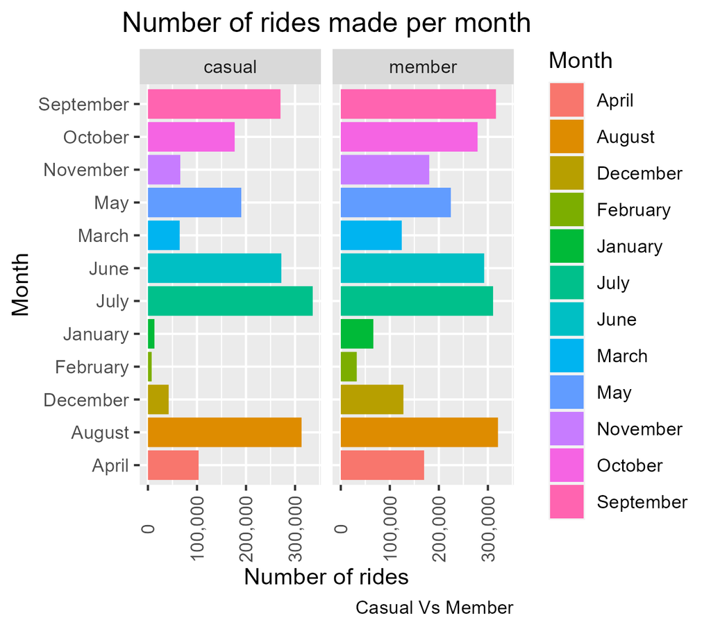

**Number of rides per Month**

```r
 #viz
  ggplot(data = year_2021_df_7, mapping = aes(y= month, fill = month)) +
    #applied the mapping here an not in the geom_bar as it will be applied to the whole built-up layers
    #as aes()in geom_function will be only applied here (hierarchy level)
    geom_bar()+
    labs(title = "Number of rides made per month",caption = "Casual Vs Member",y="Month", x="Number of rides")+
    theme(plot.title = element_text(hjust = 0.5), axis.text.x = element_text(angle = 90, vjust = 0.5))+ #centering the title
    scale_x_continuous(labels = scales :: comma)+ #removing the E expression
    scale_fill_discrete(name = "Month")+ # to change the name of the legend
    facet_grid(~usertype)

  #ggsave("plot7-Number of rides per Month.png")
```

#### Total rides(Season)

```r
#----------------------------Season-------------------
#count the total number of rides per season
  year_2021_df_7 %>%
    count(season)
```

##### Results

```r
# A tibble: 4 × 2
# Rowwise:
  season       n
  <chr>    <int>
1 Autumn 1289052
2 Spring  877172
3 Summer 1844973
4 Winter  289744
```

```r
#count the number of rides for each user-type per season
  year_2021_df_7 %>%
    group_by(usertype) %>%
    count(season)
```

##### Results

```r
# A tibble: 8 × 3
# Groups:   usertype [2]
  usertype season      n
  <chr>    <chr>   <int>
1 casual   Autumn 513155
2 casual   Spring 358365
3 casual   Summer 921297
4 casual   Winter  63014
5 member   Autumn 775897
6 member   Spring 518807
7 member   Summer 923676
8 member   Winter 226730
```

```r
#count the number of rides for each bike id per season
  year_2021_df_7 %>%
    group_by(bikeid) %>%
    count(season)
```

##### Results

```r
# A tibble: 12 × 3
# Groups:   bikeid [3]
   bikeid        season       n
   <chr>         <chr>    <int>
 1 classic_bike  Autumn  879570
 2 classic_bike  Spring  621262
 3 classic_bike  Summer 1345999
 4 classic_bike  Winter  185972
 5 docked_bike   Autumn   55259
 6 docked_bike   Spring   61410
 7 docked_bike   Summer  123686
 8 docked_bike   Winter    6646
 9 electric_bike Autumn  354223
10 electric_bike Spring  194500
11 electric_bike Summer  375288
12 electric_bike Winter   97126
```

```r
#count the number of rides for each bike id per season for each user-type
  year_2021_df_7 %>%
    group_by(usertype,bikeid) %>%
    count(season) %>%
    print(n=22)
```

##### Results

```r
# A tibble: 21 × 4
# Groups:   usertype, bikeid [6]
   usertype bikeid        season      n
   <chr>    <chr>         <chr>   <int>
 1 casual   classic_bike  Autumn 305328
 2 casual   classic_bike  Spring 207978
 3 casual   classic_bike  Summer 596506
 4 casual   classic_bike  Winter  30060
 5 casual   docked_bike   Autumn  55259
 6 casual   docked_bike   Spring  61410
 7 casual   docked_bike   Summer 123686
 8 casual   docked_bike   Winter   6645
 9 casual   electric_bike Autumn 152568
10 casual   electric_bike Spring  88977
11 casual   electric_bike Summer 201105
12 casual   electric_bike Winter  26309
13 member   classic_bike  Autumn 574242
14 member   classic_bike  Spring 413284
15 member   classic_bike  Summer 749493
16 member   classic_bike  Winter 155912
17 member   docked_bike   Winter      1
18 member   electric_bike Autumn 201655
19 member   electric_bike Spring 105523
20 member   electric_bike Summer 174183
21 member   electric_bike Winter  70817
```

```r
#find the peak month for each season according to each user-type
  year_2021_df_7 %>%
    group_by(usertype,month) %>%
    count(season) %>%
    print(n=24)
```

##### Results

```r
# A tibble: 24 × 4
# Groups:   usertype, month [24]
   usertype month     season      n
   <chr>    <chr>     <chr>   <int>
 1 casual   April     Spring 103298
 2 casual   August    Summer 313231
 3 casual   December  Winter  42237
 4 casual   February  Winter   7547
 5 casual   January   Winter  13230
 6 casual   July      Summer 336030
 7 casual   June      Summer 272036
 8 casual   March     Spring  64713
 9 casual   May       Spring 190354
10 casual   November  Autumn  65961
11 casual   October   Autumn 176865
12 casual   September Autumn 270329
13 member   April     Spring 169959
14 member   August    Summer 320594
15 member   December  Winter 127727
16 member   February  Winter  32581
17 member   January   Winter  66422
18 member   July      Summer 310626
19 member   June      Summer 292456
20 member   March     Spring 124379
21 member   May       Spring 224469
22 member   November  Autumn 180418
23 member   October   Autumn 279020
24 member   September Autumn 316459
```

##### Visualization

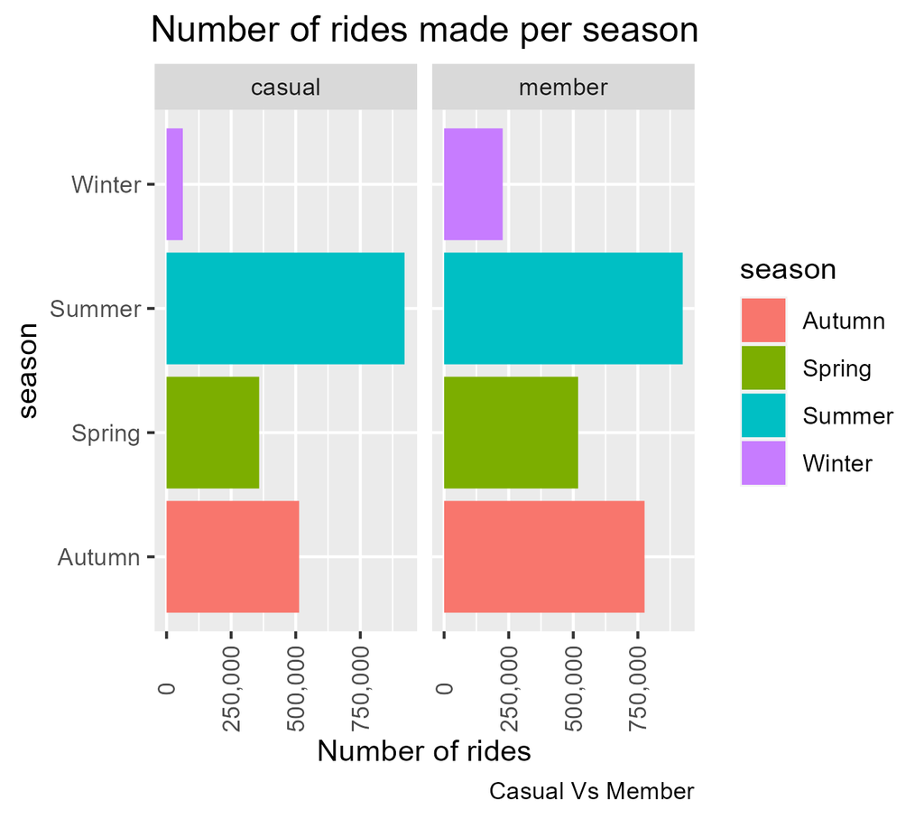

**Number of rides per season**

```r
 #viz
  ggplot(data = year_2021_df_7, mapping = aes(y= season, fill = season)) +
    #applied the mapping here an not in the geom_bar as it will be applied to the whole built-up layers
    #as aes()in geom_function will be only applied here (hierarchy level)
    geom_bar()+
    labs(title = "Number of rides made per season",caption = "Casual Vs Member",y="season", x="Number of rides")+
    theme(plot.title = element_text(hjust = 0.5), axis.text.x = element_text(angle = 90, vjust = 0.5))+ #centering the title
    scale_x_continuous(labels = scales :: comma)+ #removing the E expression
    scale_fill_discrete(name = "season")+ # to change the name of the legend
    facet_grid(~usertype)

  #ggsave("plot8-Number of rides per season.png")
```

#### Total rides(Year_quarters)

```r
#----------------------------Year Quarter-------------------
  #count the total number of rides per quarter
  year_2021_df_7 %>%
    count(year_quarter)
```

##### Results

```r
# A tibble: 4 × 2
# Rowwise:
  year_quarter       n
  <chr>          <int>
1 Q1            308872
2 Q2           1252572
3 Q3           1867269
4 Q4            872228
```

```r
#count the number of rides for each user-type per quarter
  year_2021_df_7 %>%
    group_by(usertype) %>%
    count(year_quarter)
```

##### Results

```r
# A tibble: 8 × 3
# Groups:   usertype [2]
  usertype year_quarter      n
  <chr>    <chr>         <int>
1 casual   Q1            85490
2 casual   Q2           565688
3 casual   Q3           919590
4 casual   Q4           285063
5 member   Q1           223382
6 member   Q2           686884
7 member   Q3           947679
8 member   Q4           587165
```

```r
#count the number of rides for each bike id per quarter
  year_2021_df_7 %>%
    group_by(bikeid) %>%
    count(year_quarter)
```

##### Results

```r
# A tibble: 12 × 3
# Groups:   bikeid [3]
   bikeid        year_quarter       n
   <chr>         <chr>          <int>
 1 classic_bike  Q1            230752
 2 classic_bike  Q2            883460
 3 classic_bike  Q3           1378121
 4 classic_bike  Q4            540470
 5 docked_bike   Q1             13776
 6 docked_bike   Q2             90334
 7 docked_bike   Q3            112858
 8 docked_bike   Q4             30033
 9 electric_bike Q1             64344
10 electric_bike Q2            278778
11 electric_bike Q3            376290
12 electric_bike Q4            301725
```

```r
#count the number of rides for each bike id per quarter for each user-type
  year_2021_df_7 %>%
    group_by(usertype,bikeid) %>%
    count(year_quarter) %>%
    print(n=22)
```

##### Results

```r
# A tibble: 21 × 4
# Groups:   usertype, bikeid [6]
   usertype bikeid        year_quarter      n
   <chr>    <chr>         <chr>         <int>
 1 casual   classic_bike  Q1            51172
 2 casual   classic_bike  Q2           336560
 3 casual   classic_bike  Q3           608146
 4 casual   classic_bike  Q4           143994
 5 casual   docked_bike   Q1            13775
 6 casual   docked_bike   Q2            90334
 7 casual   docked_bike   Q3           112858
 8 casual   docked_bike   Q4            30033
 9 casual   electric_bike Q1            20543
10 casual   electric_bike Q2           138794
11 casual   electric_bike Q3           198586
12 casual   electric_bike Q4           111036
13 member   classic_bike  Q1           179580
14 member   classic_bike  Q2           546900
15 member   classic_bike  Q3           769975
16 member   classic_bike  Q4           396476
17 member   docked_bike   Q1                1
18 member   electric_bike Q1            43801
19 member   electric_bike Q2           139984
20 member   electric_bike Q3           177704
21 member   electric_bike Q4           190689
```

```r
  #find the peak month for each quarter according to each user-type
  year_2021_df_7 %>%
    group_by(usertype,month) %>%
    count(year_quarter) %>%
    print(n=24)
```

##### Results

```r
# A tibble: 24 × 4
# Groups:   usertype, month [24]
   usertype month     year_quarter      n
   <chr>    <chr>     <chr>         <int>
 1 casual   April     Q2           103298
 2 casual   August    Q3           313231
 3 casual   December  Q4            42237
 4 casual   February  Q1             7547
 5 casual   January   Q1            13230
 6 casual   July      Q3           336030
 7 casual   June      Q2           272036
 8 casual   March     Q1            64713
 9 casual   May       Q2           190354
10 casual   November  Q4            65961
11 casual   October   Q4           176865
12 casual   September Q3           270329
13 member   April     Q2           169959
14 member   August    Q3           320594
15 member   December  Q4           127727
16 member   February  Q1            32581
17 member   January   Q1            66422
18 member   July      Q3           310626
19 member   June      Q2           292456
20 member   March     Q1           124379
21 member   May       Q2           224469
22 member   November  Q4           180418
23 member   October   Q4           279020
24 member   September Q3           316459
```

##### Visualization

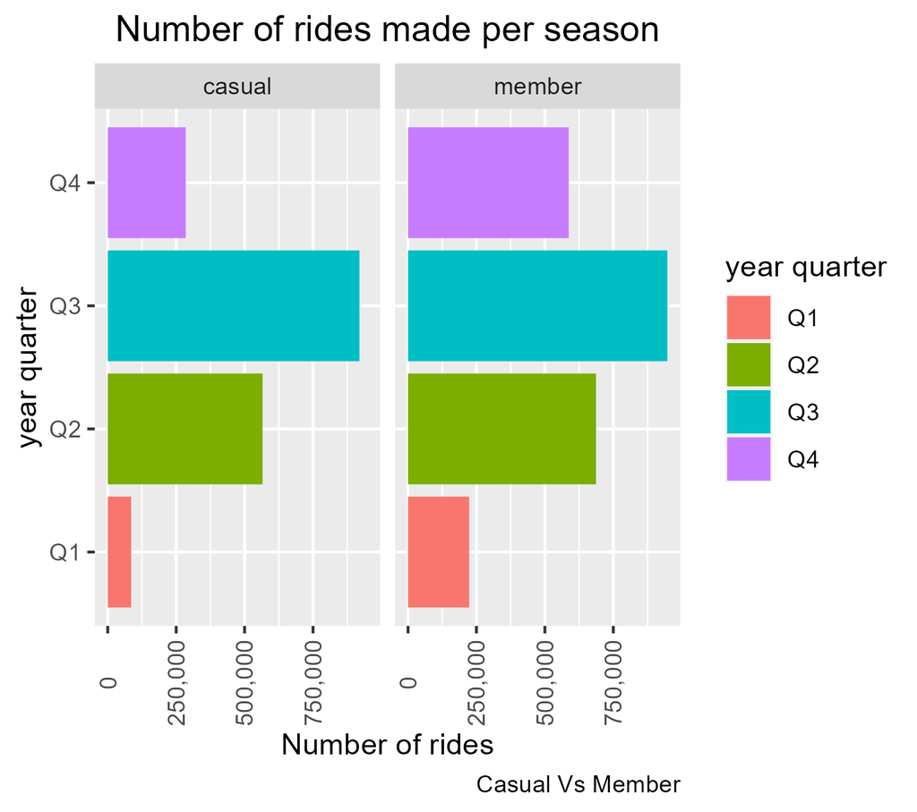

**Number of rides per year quarters**

```r
 #viz
  ggplot(data = year_2021_df_7, mapping = aes(y= year_quarter, fill = year_quarter)) +
    #applied the mapping here an not in the geom_bar as it will be applied to the whole built-up layers
    #as aes()in geom_function will be only applied here (hierarchy level)
    geom_bar()+
    labs(title = "Number of rides made per season",caption = "Casual Vs Member",y="year quarter", x="Number of rides")+
    theme(plot.title = element_text(hjust = 0.5), axis.text.x = element_text(angle = 90, vjust = 0.5))+ #centering the title
    scale_x_continuous(labels = scales :: comma)+ #removing the E expression
    scale_fill_discrete(name = "year quarter")+ # to change the name of the legend
    facet_grid(~usertype)

  #ggsave("plot9-Number of rides per year quarter.png")
```

#### Total rides(From_station)

```r
#----------------------------station-------------------
#count the number of the rides by from_station
 year_2021_df_7 %>%
    count(from_station_name) %>%
    print(n=836)
```

##### Results

```r
# A tibble: 836 × 2
# Rowwise:
   from_station_name              n
   <chr>                      <int>
 1 2112 w peterson ave          802
 2 63rd st beach               1244
 3 900 w harrison st           7685
 4 aberdeen st & jackson blvd 10997
 5 aberdeen st & monroe st    10359
 6 aberdeen st & randolph st   9218
 7 ada st & 113th st             30
 8 ada st & washington blvd    8414
 9 adler planetarium          12773
10 albany ave & 26th st         228
# … with 826 more rows
# ℹ Use `print(n = ...)` to see more rows
```

```r
#count the number of rides by from_station for each user-type
  year_2021_df_7 %>%
    group_by(usertype) %>%
    count(from_station_name) %>%
    print(n=1637)
```

##### Results

```r
# A tibble: 1,637 × 3
# Groups:   usertype [2]
   usertype from_station_name              n
   <chr>    <chr>                      <int>
 1 casual   2112 w peterson ave          320
 2 casual   63rd st beach                727
 3 casual   900 w harrison st           2273
 4 casual   aberdeen st & jackson blvd  3285
 5 casual   aberdeen st & monroe st     3562
 6 casual   aberdeen st & randolph st   3598
 7 casual   ada st & 113th st             20
 8 casual   ada st & washington blvd    2807
 9 casual   adler planetarium           7986
10 casual   albany ave & 26th st         127
# … with 1,627 more rows
# ℹ Use `print(n = ...)` to see more rows
```

```r
#count the rides used by each type of bikes from the stations
  year_2021_df_7 %>%
    group_by(bikeid) %>%
    count(from_station_name) %>%
    print(n=3000)
```

##### Results

```r
# A tibble: 2,193 × 3
# Groups:   bikeid [3]
   bikeid       from_station_name              n
   <chr>        <chr>                      <int>
 1 classic_bike 2112 w peterson ave          504
 2 classic_bike 63rd st beach                811
 3 classic_bike 900 w harrison st           5688
 4 classic_bike aberdeen st & jackson blvd  7942
 5 classic_bike aberdeen st & monroe st     7461
 6 classic_bike aberdeen st & randolph st   6397
 7 classic_bike ada st & 113th st              7
 8 classic_bike ada st & washington blvd    6174
 9 classic_bike adler planetarium           8609
10 classic_bike albany ave & 26th st         143
# … with 2,183 more rows
# ℹ Use `print(n = ...)` to see more rows
```

```r
#count the rides using the timing, day and season per each user-type
  year_2021_df_7 %>%
    group_by(usertype, bikeid, start_timing) %>%
    count(from_station_name) %>%
    print(n=4000)
```

##### Results

```r
# A tibble: 13,700 × 5
# Groups:   usertype, bikeid, start_timing [21]
   usertype bikeid       start_timing from_station_name              n
   <chr>    <chr>        <chr>        <chr>                      <int>
 1 casual   classic_bike Afternoon    2112 w peterson ave           61
 2 casual   classic_bike Afternoon    63rd st beach                175
 3 casual   classic_bike Afternoon    900 w harrison st            441
 4 casual   classic_bike Afternoon    aberdeen st & jackson blvd   739
 5 casual   classic_bike Afternoon    aberdeen st & monroe st      787
 6 casual   classic_bike Afternoon    aberdeen st & randolph st    640
 7 casual   classic_bike Afternoon    ada st & 113th st              3
 8 casual   classic_bike Afternoon    ada st & washington blvd     492
 9 casual   classic_bike Afternoon    adler planetarium           2296
10 casual   classic_bike Afternoon    albany ave & 26th st          23
# … with 13,690 more rows
# ℹ Use `print(n = ...)` to see more rows
```

```r
year_2021_df_7 %>%
    group_by(usertype, bikeid, day_of_order) %>%
    count(from_station_name) %>%
    print(n=4000)
```

##### Results

```r
# A tibble: 23,385 × 5
# Groups:   usertype, bikeid, day_of_order [36]
   usertype bikeid       day_of_order from_station_name                 n
   <chr>    <chr>        <chr>        <chr>                         <int>
 1 casual   classic_bike Friday       2112 w peterson ave              16
 2 casual   classic_bike Friday       63rd st beach                    46
 3 casual   classic_bike Friday       900 w harrison st               192
 4 casual   classic_bike Friday       aberdeen st & jackson blvd      280
 5 casual   classic_bike Friday       aberdeen st & monroe st         325
 6 casual   classic_bike Friday       aberdeen st & randolph st       337
 7 casual   classic_bike Friday       ada st & washington blvd        276
 8 casual   classic_bike Friday       adler planetarium               616
 9 casual   classic_bike Friday       albany ave & 26th st             11
10 casual   classic_bike Friday       albany ave & bloomingdale ave   144
# … with 23,375 more rows
# ℹ Use `print(n = ...)` to see more rows
```

```r
year_2021_df_7 %>%
    group_by(usertype, bikeid, season) %>%
    count(from_station_name) %>%
    print(n=4000)
```

##### Results

```r
# A tibble: 13,146 × 5
# Groups:   usertype, bikeid, season [21]
   usertype bikeid       season from_station_name                 n
   <chr>    <chr>        <chr>  <chr>                         <int>
 1 casual   classic_bike Autumn 2112 w peterson ave              53
 2 casual   classic_bike Autumn 63rd st beach                    81
 3 casual   classic_bike Autumn 900 w harrison st               488
 4 casual   classic_bike Autumn aberdeen st & jackson blvd      637
 5 casual   classic_bike Autumn aberdeen st & monroe st         512
 6 casual   classic_bike Autumn aberdeen st & randolph st       592
 7 casual   classic_bike Autumn ada st & washington blvd        502
 8 casual   classic_bike Autumn adler planetarium              1044
 9 casual   classic_bike Autumn albany ave & 26th st             19
10 casual   classic_bike Autumn albany ave & bloomingdale ave   239
# … with 13,136 more rows
# ℹ Use `print(n = ...)` to see more rows
```

##### Visualization

```r
#viz
#create a data set for the top 5 stations filtered per user-type
  top_10_stations <- year_2021_df_7 %>%
    group_by(usertype) %>%
    count(from_station_name, sort= TRUE) %>%
    slice_head(n=5)
str(top_10_stations)
```

##### Results

```r
# A tibble: 10 × 3
# Groups:   usertype [2]
  usertype        from_station_name     n
1    casual  streeter dr & grand ave 54102
2    casual          millennium park 26792
3    casual    michigan ave & oak st 23576
4    casual           shedd aquarium 20009
5    casual    wells st & concord ln 18177
6    member        clark st & elm st 23172
7    member kingsbury st & kinzie st 22229
8    member    wells st & concord ln 22189
9    member        wells st & elm st 19627
10   member    dearborn st & erie st 18178
```

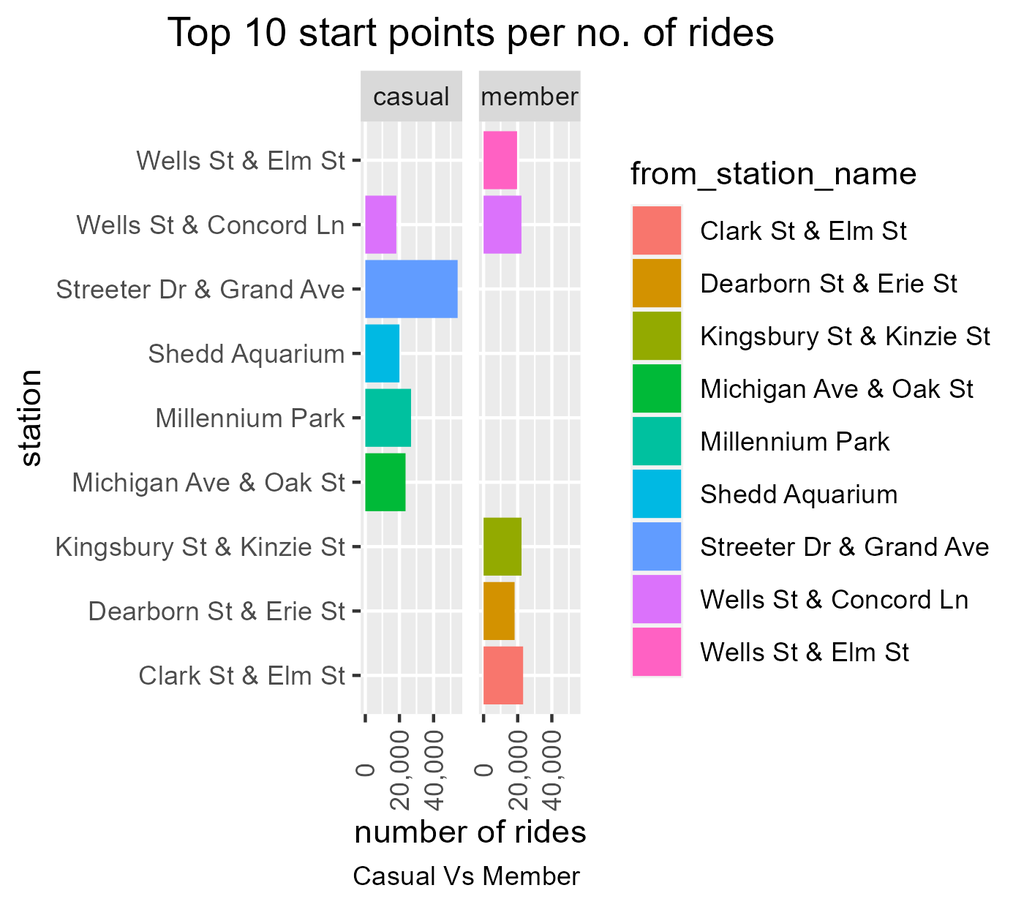

**Top 10 start points per no. of rides**

```r
#Visualization
 ggplot(data = top_10_stations, mapping = aes(y= from_station_name,x= n, fill =from_station_name )) +
    #applied the mapping here an not in the geom_bar as it will be applied to the whole built-up layers
    #as aes()in geom_function will be only applied here (hierarchy level)
    geom_col()+
    labs(title = "Top 10 start points per no. of rides",caption = "Casual Vs Member",x="number of rides", y="station")+
    theme(plot.title = element_text(hjust = 0.5), axis.text.x = element_text(angle = 90, vjust = 0.5))+ #centering the title
    scale_x_continuous(labels = scales :: comma)+ #removing the E expression
    facet_grid(~usertype)

  #ggsave("plot10-Top 10 start points per no. of rides.png")
```

#### Time duration taken per each user_type under different factors

#### Time duration (General)

```r
#-----------------------------------Time duration of the trip---------------
    max(year_2021_df_7$time_duration)
    min(year_2021_df_7$time_duration)
    mean(year_2021_df_7$time_duration)
    sum(year_2021_df_7$time_duration)
    summary(year_2021_df_7$time_duration)
```

##### Results

```r
max(year_2021_df_7$time_duration)
 55944
min(year_2021_df_7$time_duration)
1
mean(year_2021_df_7$time_duration)
 20.54499
sum(year_2021_df_7$time_duration)
 88362808
summary(year_2021_df_7$time_duration)
    Min.  1st Qu.   Median     Mean  3rd Qu.     Max.
    1.00     7.00    12.00    20.54    21.00 55944.00
```

#### Time duration (user-type summary)

```r
#summary(user-type)
    year_2021_df_7 %>%
      group_by(usertype) %>%
      summarise(first_quartile = as.numeric(quantile(time_duration,0.25)),
                second_quartile = as.numeric(quantile(time_duration,0.50)),
                median_time_duration = median(time_duration),
                mean_time_duration = mean(time_duration),
                third_quartile = as.numeric(quantile(time_duration,0.75)),
                IQR = as.numeric(quantile(time_duration,0.75))-as.numeric(quantile(time_duration,0.25)),
                #allowed limits so if the values fall outside them they aren't considered as outliers
                max_time_duration = as.numeric(quantile(time_duration,0.75)) + 1.5*(as.numeric(quantile(time_duration,0.75))-as.numeric(quantile(time_duration,0.25))),
                min_time_duration=as.numeric(quantile(time_duration,0.25))- 1.5*(as.numeric(quantile(time_duration,0.75))-as.numeric(quantile(time_duration,0.25))),
                max_time_duration_outlier = max(time_duration),
                min_time_duration_outlier = min(time_duration))
```

##### Results

```r
# A tibble: 2 × 11
  usertype first_quartile second_quartile median_time_du…¹ mean_…² third…³   IQR max_t…⁴ min_t…⁵ max_t…⁶ min_t…⁷
  <chr>             <dbl>           <dbl>            <dbl>   <dbl>   <dbl> <dbl>   <dbl>   <dbl>   <dbl>   <dbl>
1 casual                9              16               16    30.4      28    19    56.5   -19.5   55944       1
2 member                6              10               10    13.1      16    10    31      -9      1496       1
# … with abbreviated variable names ¹median_time_duration, ²mean_time_duration, ³third_quartile,
#   ⁴max_time_duration, ⁵min_time_duration, ⁶max_time_duration_outlier, ⁷min_time_duration_outlier
```

##### Visualization

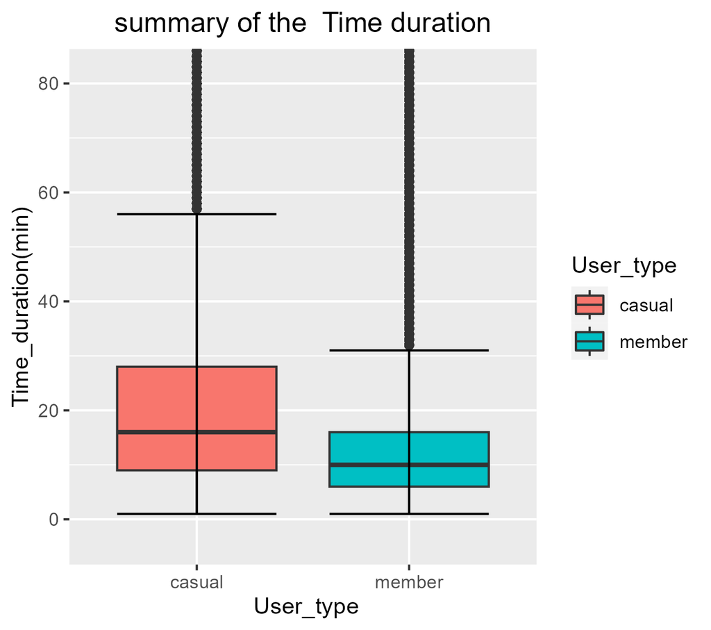

**Statistical summary of the Time duration of trips for each user type**

```r
#viz
    ggplot(year_2021_df_7, mapping = aes(x=usertype, y=time_duration, fill= usertype))+
      geom_boxplot()+
      stat_boxplot(geom = "errorbar")+
      labs(title = "summary of the  Time duration", x=" User_type", y="Time_duration(min)")+
      theme(plot.title = element_text(hjust = 0.5))+ #centering the title
      scale_fill_discrete(name = "User_type")+
      coord_cartesian(ylim = c(as.numeric(quantile(year_2021_df_7$time_duration,0.25))+10-1.5*(as.numeric(quantile(year_2021_df_7$time_duration,0.75))-as.numeric(quantile(year_2021_df_7$time_duration,0.25))),as.numeric(quantile(year_2021_df_7$time_duration,0.75))+40+1.5*(as.numeric(quantile(year_2021_df_7$time_duration,0.75))-as.numeric(quantile(year_2021_df_7$time_duration,0.25)))))

    #saving the plot
    #ggsave("plot11-Statistical summary of the  Time duration of trips for each user type.png")
```

#### Total sum of time duration per user_type

```r
#total of duration for the whole trips for each user-type
    year_2021_df_7 %>%
      group_by(usertype) %>%
      summarize(sum(time_duration))
```

##### Results

```r
# A tibble: 2 × 2
  usertype `sum(time_duration)`
  <chr>                   <dbl>
1 casual               56374447
2 member               31988361
```